# Population Ecology HW1

Tess Hooper

1/15/2020

## Question 1.

- Availability of resources (e.g. water, food) will affect where plants or animals are distributed. In this case I would expect the location of high-density patches to be inconsistent from year to year, as the resources may change. For instance, if certain foraging plants are abundant in one area, then that is where we might find ungulates in a given year. However, if they deplete that resource then that group of ungulates may need to move locations.
- Predation is another factor that affects many species. Prey species may form patchy groups to avoid predation. If resources remain consistent then I would expect high density areas to remain similar from year to year.
- Plants are static and therefore cannot move patches. Depending on their seed dispersal capabilities, the patches will remain relatively the same year to year.

# Eurkea Dune Grass

## Question 2.

```
##
##  Two Sample t-test
##
## data:  swallenia2$count_2009 and swallenia2$count_2010
## t = -0.81791, df = 20, p-value = 0.423
## alternative hypothesis: true difference in means is not equal to 0
## 95 percent confidence interval:
##  -140.07803   61.16893
## sample estimates:
## mean of x mean of y
##  61.90909 101.36364
```

For this analysis I chose $\alpha = 0.05$ value because this is a common standard that we have used in the past. This significance level signifies a 5% risk of concluding that a difference exists when there is actually no difference. The t-test results show (p = 0.42). Based on this analysis, there was no significant change in mean abundance of Swallenia between 2009 and 2010, since this p-value was greater than 0.05.

## Question 3.

```
##
##  Paired t-test
##
## data:  swallenia2$count_2009 and swallenia2$count_2010
## t = -2.4508, df = 10, p-value = 0.03421
## alternative hypothesis: true difference in means is not equal to 0
## 95 percent confidence interval:
##  -75.324830  -3.584261
## sample estimates:
## mean of the differences
##               -39.45455
```

When conducting a two-sided paired t-test, the resulting p-value is 0.03421. This gives us enough evidence to reject the null hypothesis, meaning we have sufficient evidence to suggest that there is a significant difference in mean abundance between 2009 and 2010. The mean of the differences is -39.45, indicating that there was a decline in mean abudnace between the two years.

## Question 4.

I believe the paired t-test is more appropriate for this analysis because the plants are counted in the same plots each year. Therefore, the count for year 2 in a plot would be associated with the count from year 1 in the same plot. That being said, there may be additional growth in some plots due to seed dispersal from surrounding plots (depending on how the Eureka dunes proliferate).

## Question 5.

Dear Park Superintendant, Upon evaluating the population of Eureka dune grass on Saline Dune between 2009 and 2010, I have concluded that there was a significant decline in dune mean abundance. My team and I counted dune abundance within 11 plots across the dune study area throughout the 2009 and 2010. Our results from a paired t-test statistical analysis indicate a statistical difference in mean abundance between the study period. The park should continue to monitor the Eureka dune grass populations so we can get a more robust dataset.

# Yellowstone Grizzly Bears

# Question 6.

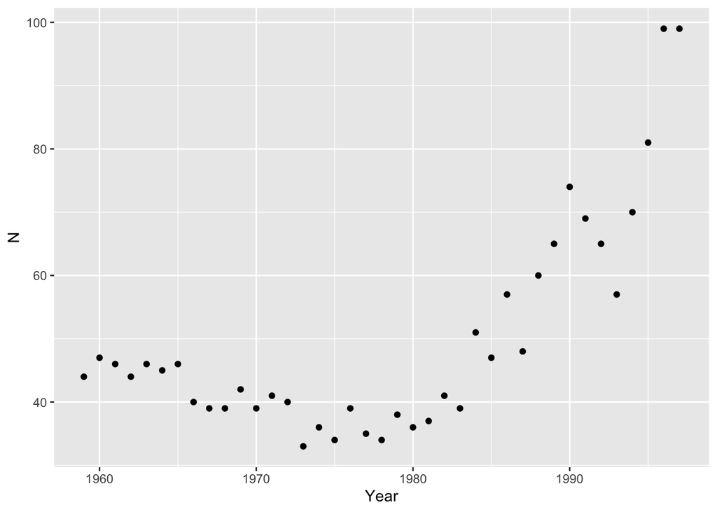

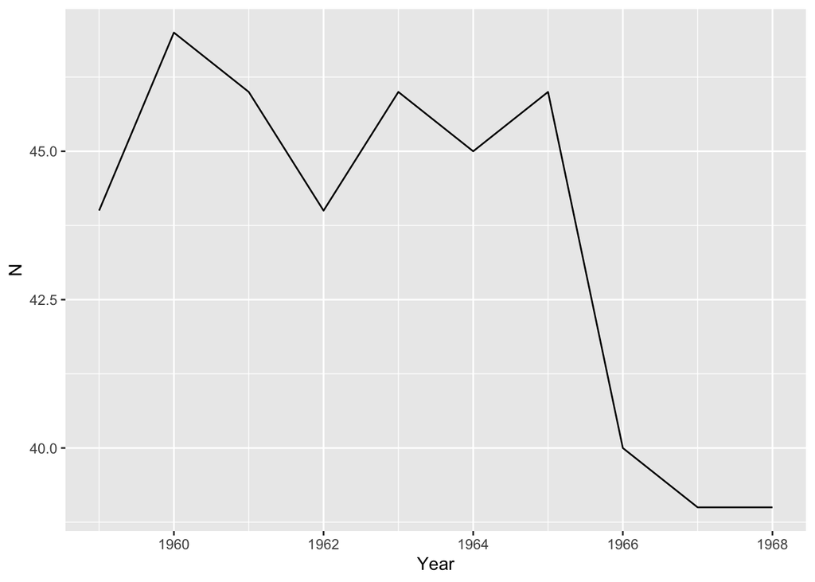

```
##
## Call:
## lm(formula = N ~ Year, data = grizzly_68)
##
## Residuals:
##     Min      1Q  Median      3Q     Max
## -3.0364 -1.5591 -0.1273  1.5182  3.5455
##
## Coefficients:
##              Estimate Std. Error t value Pr(>|t|)
## (Intercept) 1543.0000   472.9413   3.263   0.0115 *
## Year          -0.7636     0.2409  -3.170   0.0132 *
## ---
## Signif. codes:  0 '***' 0.001 '**' 0.01 '*' 0.05 '.' 0.1 ' ' 1
##
## Residual standard error: 2.188 on 8 degrees of freedom
## Multiple R-squared:  0.5568, Adjusted R-squared:  0.5014
## F-statistic: 10.05 on 1 and 8 DF,  p-value: 0.01319
```

```
##
## Call:
## lm(formula = N ~ Year, data = grizzly_68)
##
## Residuals:
##     Min      1Q  Median      3Q     Max
## -3.0364 -1.5591 -0.1273  1.5182  3.5455
##
## Coefficients:
##              Estimate Std. Error t value Pr(>|t|)
## (Intercept) 1543.0000   472.9413   3.263   0.0115 *
## Year          -0.7636     0.2409  -3.170   0.0132 *
## ---
## Signif. codes:  0 '***' 0.001 '**' 0.01 '*' 0.05 '.' 0.1 ' ' 1
##
## Residual standard error: 2.188 on 8 degrees of freedom
## Multiple R-squared:  0.5568, Adjusted R-squared:  0.5014
## F-statistic: 10.05 on 1 and 8 DF,  p-value: 0.01319
```

```
## # A tibble: 2 x 5
##   term        estimate std.error statistic p.value
##   <chr>          <dbl>     <dbl>     <dbl>   <dbl>
## 1 (Intercept) 1543.      473.         3.26  0.0115
## 2 Year          -0.764     0.241     -3.17  0.0132
```

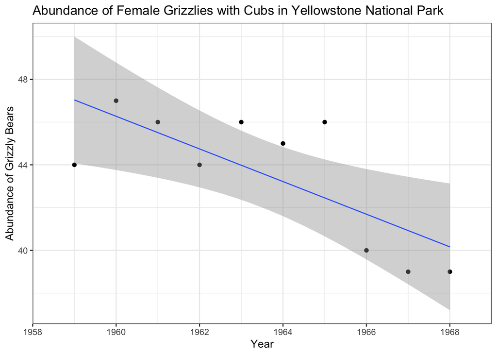

The linear regression indicates that there was a significant decline in bear population between 1959 and 1968. The rate at which the bears declined was 0.7636 bears per year. The equation for the model is $Abundance~of~Grizzly~Bears = -0.7636*Year + 1543$. The results from the linear regression show a standard error of 2.188 and p-value of 0.013. When looking at the graph, the results seem to make sense. There is seemingly a drastic decline between 1965 and 1966 especially.

## Question 7.

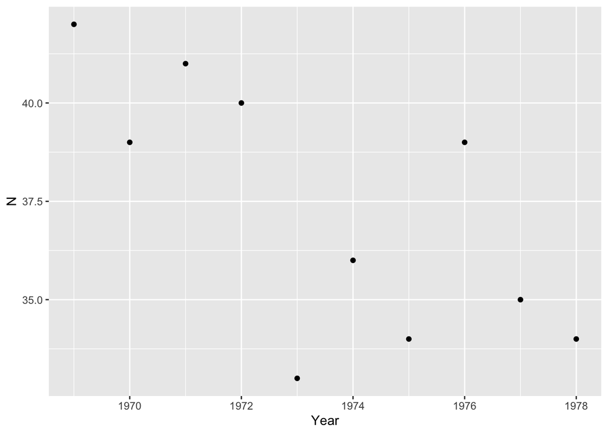

```
##
## Call:
## lm(formula = N ~ Year, data = grizzly_78)
##
## Coefficients:
## (Intercept)         Year
##   1532.3758      -0.7576
```

```
##
## Call:
## lm(formula = N ~ Year, data = grizzly_78)
##
## Residuals:
##     Min      1Q  Median      3Q     Max
## -4.6788 -0.9439  0.2303  1.4955  3.5939
##
## Coefficients:
##              Estimate Std. Error t value Pr(>|t|)
## (Intercept) 1532.3758   536.3641   2.857   0.0213 *
## Year          -0.7576     0.2718  -2.787   0.0237 *
## ---
## Signif. codes:  0 '***' 0.001 '**' 0.01 '*' 0.05 '.' 0.1 ' ' 1
##
## Residual standard error: 2.469 on 8 degrees of freedom
## Multiple R-squared:  0.4927, Adjusted R-squared:  0.4293
## F-statistic:  7.77 on 1 and 8 DF,  p-value: 0.02365
```

```
## # A tibble: 2 x 5
##   term        estimate std.error statistic p.value
##   <chr>          <dbl>     <dbl>     <dbl>   <dbl>
## 1 (Intercept) 1532.      536.         2.86  0.0213
## 2 Year          -0.758     0.272     -2.79  0.0237
```

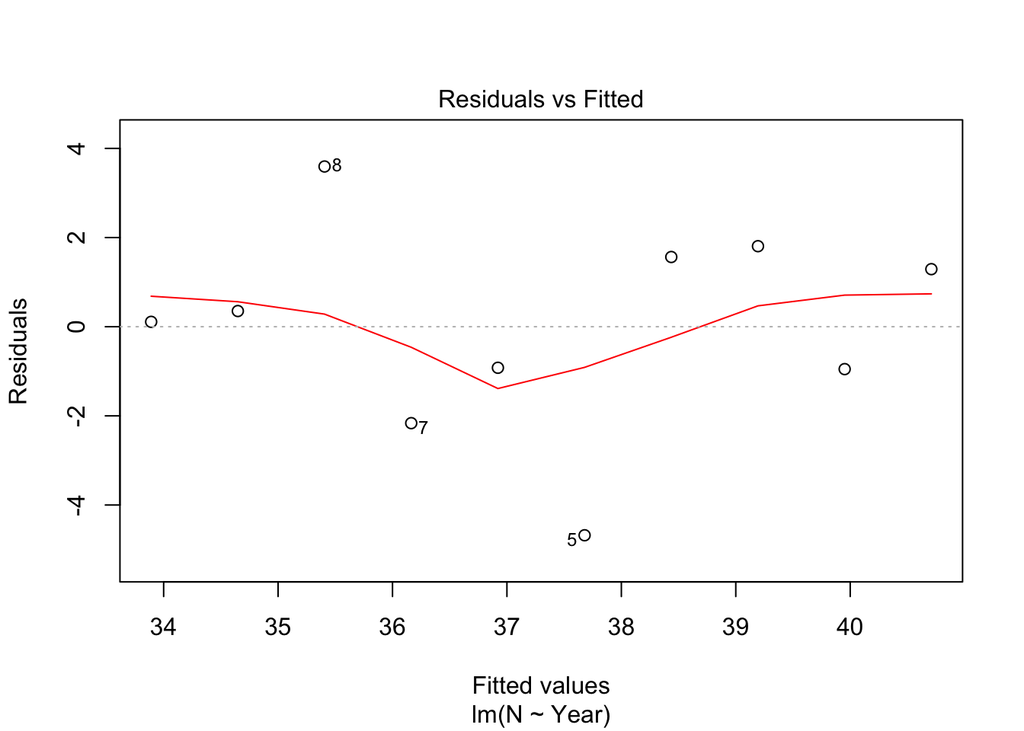

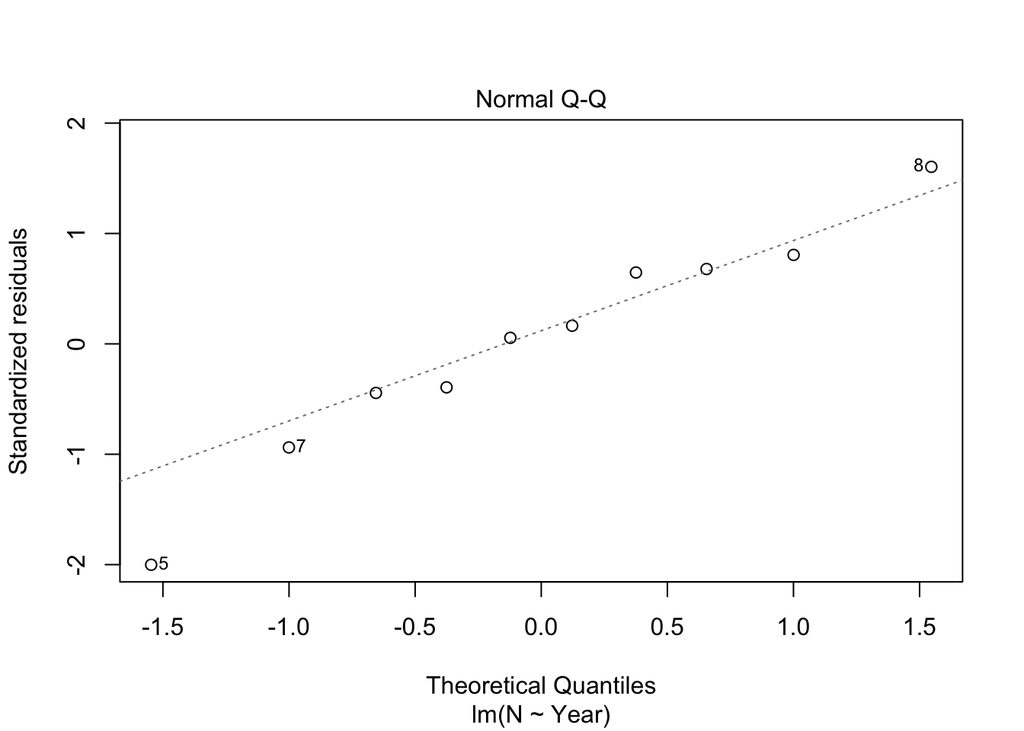

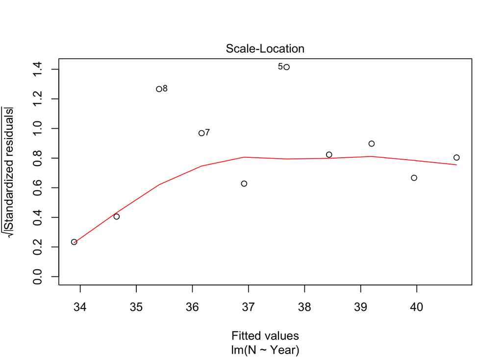

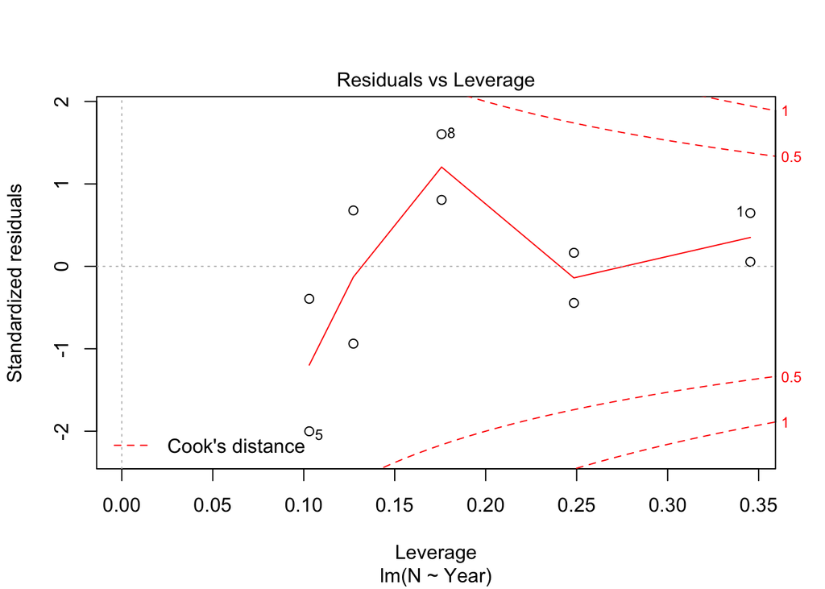

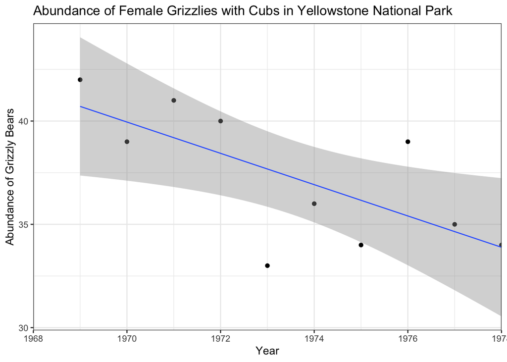

The linear regression indicates that there was a significant decline in bear population between 1969 and 1978. The rate at which the bears declined was 0.7576 bears per year. The equation for the model is $Abundance~of~Grizzly~Bears = -0.7576*Year + 1532$. The results from the linear regression show a standard error of 2.469 and p-value of 0.02. When comparing the results from 1959-1968 and 1969-1978, the bear population continued to decline at a similar rate (1969-1978 was slightly slower). Because the standard error bars overlap, there was no significant difference in decline between the two time periods.

## Question 8.

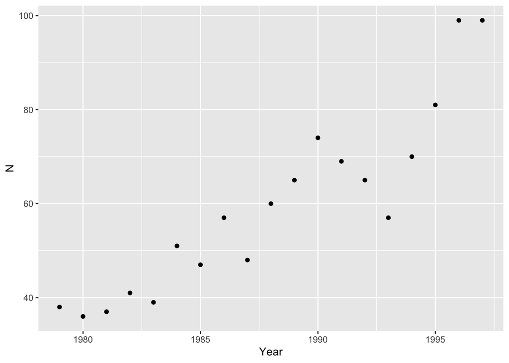

```
##
## Call:
## lm(formula = N ~ Year, data = grizzly_97)
##
## Coefficients:
## (Intercept)         Year
##   -6211.288        3.154
```

```
##
## Call:
## lm(formula = N ~ Year, data = grizzly_97)
##
## Residuals:
##      Min       1Q   Median       3Q      Max
## -18.4035  -4.0140   0.2947   3.8316  14.1333
##
## Coefficients:
##               Estimate Std. Error t value Pr(>|t|)
## (Intercept) -6211.2877   650.9227  -9.542 3.06e-08 ***
## Year            3.1544     0.3274   9.634 2.67e-08 ***
## ---
## Signif. codes:  0 '***' 0.001 '**' 0.01 '*' 0.05 '.' 0.1 ' ' 1
##
## Residual standard error: 7.817 on 17 degrees of freedom
## Multiple R-squared:  0.8452, Adjusted R-squared:  0.8361
## F-statistic: 92.81 on 1 and 17 DF,  p-value: 2.667e-08
```

```
## # A tibble: 2 x 5
##   term        estimate std.error statistic      p.value
##   <chr>          <dbl>     <dbl>     <dbl>        <dbl>
## 1 (Intercept) -6211.     651.        -9.54 0.0000000306
## 2 Year            3.15     0.327      9.63 0.0000000267
```

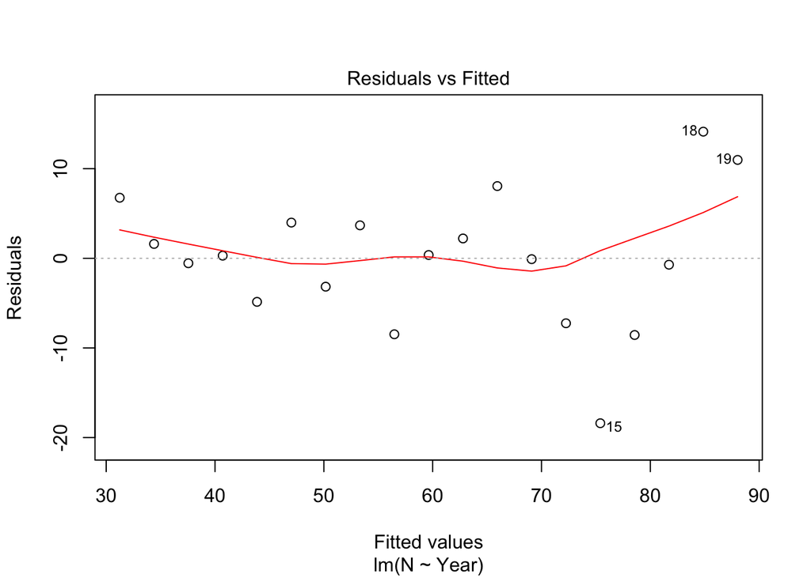

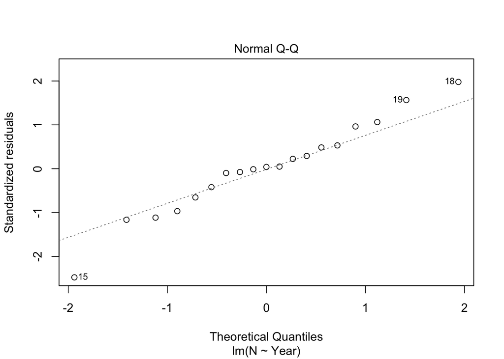

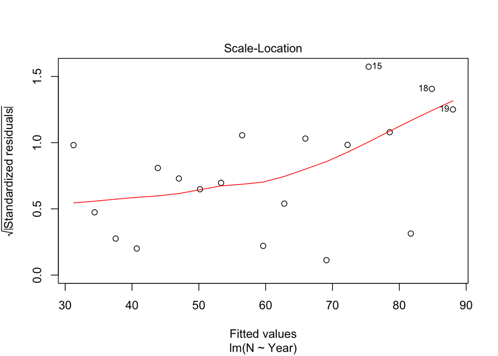

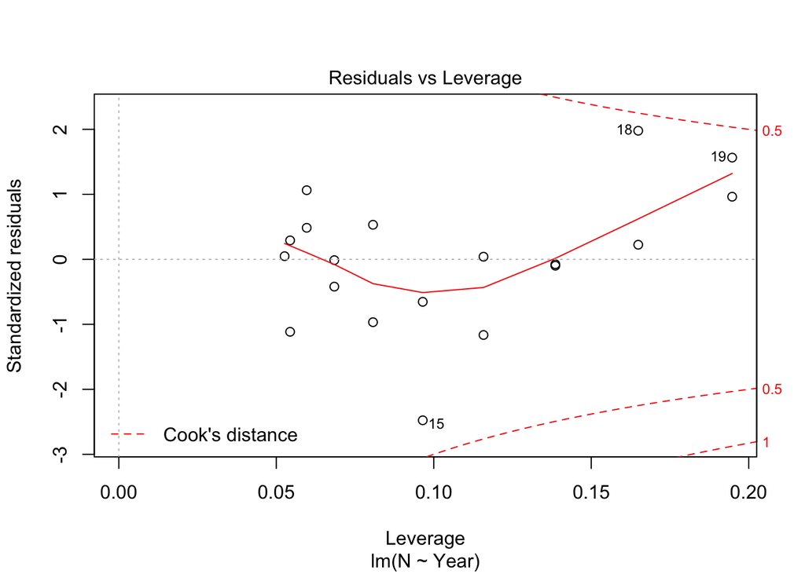

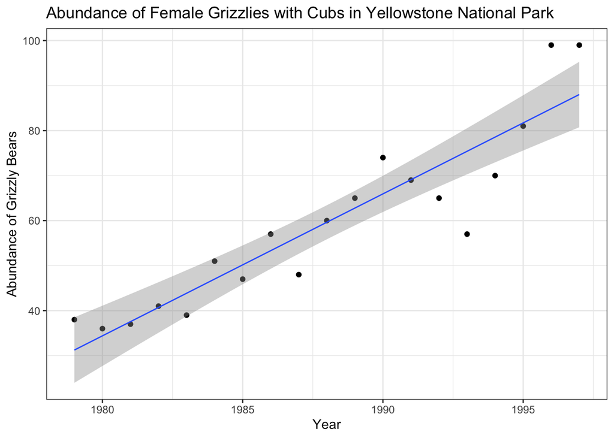

The linear regression indicates that there was a significant increase in bear population between 1979 and 1997. The rate at which the bears inceased was 3.15 bears per year. The equation for the model is $Abundance~of~Grizzly~Bears = 3.15*Year - 6211$. The results from the linear regression show a standard error of 7.817 and p-value of 2.667e-08.

## Question 9.

Dear Park Superintendant, Following the dump closures in the park between 1968 and 1971, there was a significant decline in grizzly bear populations, specifically adult females with cubs, between 1959-1978. This could have been due to the sudden decrease in resources for the bears (e.g. food). However, between 1979-1997, about 10 years after the dump closures there began an increase in bear populations. While this is a promising sign, continued bear population monitoring is encouraged, particularly as the park becomes more and more popular with tourists.